# ass2

XU Ke_3035809704

2020/11/26

# Q1

## Q1.1

```r
rm(list=ls())
```

```r
library(ISLR)
summary(Default)
```

```
##  default    student       balance           income
##  No :9667   No :7056   Min.   :   0.0   Min.   :  772
##  Yes: 333   Yes:2944   1st Qu.: 481.7   1st Qu.:21340
##                        Median : 823.6   Median :34553
##                        Mean   : 835.4   Mean   :33517
##                        3rd Qu.:1166.3   3rd Qu.:43808
##                        Max.   :2654.3   Max.   :73554
```

```r
ols1 <- glm(default~student, data=Default, family=binomial )
summary(ols1)
```

```
##
## Call:
## glm(formula = default ~ student, family = binomial, data = Default)
##
## Deviance Residuals:
##     Min       1Q   Median       3Q      Max
## -0.2970  -0.2970  -0.2434  -0.2434   2.6585
##
## Coefficients:
##             Estimate Std. Error z value Pr(>|z|)
## (Intercept) -3.50413    0.07071  -49.55  < 2e-16 ***
## studentYes   0.40489    0.11502    3.52 0.000431 ***
## ---
## Signif. codes:  0 '***' 0.001 '**' 0.01 '*' 0.05 '.' 0.1 ' ' 1
##
## (Dispersion parameter for binomial family taken to be 1)
##
##     Null deviance: 2920.6  on 9999  degrees of freedom
## Residual deviance: 2908.7  on 9998  degrees of freedom
## AIC: 2912.7
##
## Number of Fisher Scoring iterations: 6
```

Student is a significant variable of default. Comparing to non-student, student makes log odds of default increase 0.40489, which means that student is more likely to default.

## Q1.2

### i

```r
stu1<-ifelse(Default$student == 'Yes', 0, 1)
ols2 <- glm(default~stu1, data=Default, family=binomial )
summary(ols2)
```

```
##
## Call:
## glm(formula = default ~ stu1, family = binomial, data = Default)
##
## Deviance Residuals:
##     Min       1Q   Median       3Q      Max
## -0.2970  -0.2970  -0.2434  -0.2434   2.6585
##
## Coefficients:
##             Estimate Std. Error z value Pr(>|z|)
## (Intercept) -3.09924    0.09071  -34.16  < 2e-16 ***
## stu1        -0.40489    0.11502   -3.52 0.000431 ***
## ---
## Signif. codes:  0 '***' 0.001 '**' 0.01 '*' 0.05 '.' 0.1 ' ' 1
##
## (Dispersion parameter for binomial family taken to be 1)
##
##     Null deviance: 2920.6  on 9999  degrees of freedom
## Residual deviance: 2908.7  on 9998  degrees of freedom
## AIC: 2912.7
##
## Number of Fisher Scoring iterations: 6
```

$$p(x)=\frac{e^{-3.09924-0.40489*x}}{1+e^{-3.09924-0.40489*x}}$$

### ii

$$l(\beta_0,\beta)=\Pi_{i:y_i=1}(\hat{P}(default|student_i))\Pi_{i:y_i=0}(1-(\hat{P}(default|student_i))$$

### iii

In Q1.1: 1 for student and 0 for non-student, the coefficient is what student is likely to default. In Q1.2: 0 for student and 1 for non-student, the coefficient is what non-student is likely to default. The coefficients of student in two model are the same value with opposite signals.

## Q1.3

### i

```r
ols3 <- glm(default ~ student+balance+income, data=Default, family=binomial)
summary(ols3)
```

```
##
## Call:
## glm(formula = default ~ student + balance + income, family = binomial,
##     data = Default)
##
## Deviance Residuals:
##     Min       1Q   Median       3Q      Max
## -2.4691  -0.1418  -0.0557  -0.0203   3.7383
##
## Coefficients:
##               Estimate Std. Error z value Pr(>|z|)
## (Intercept) -1.087e+01  4.923e-01 -22.080  < 2e-16 ***
## studentYes  -6.468e-01  2.363e-01  -2.738  0.00619 **
## balance      5.737e-03  2.319e-04  24.738  < 2e-16 ***
## income       3.033e-06  8.203e-06   0.370  0.71152
## ---
## Signif. codes:  0 '***' 0.001 '**' 0.01 '*' 0.05 '.' 0.1 ' ' 1
##
## (Dispersion parameter for binomial family taken to be 1)
##
##     Null deviance: 2920.6  on 9999  degrees of freedom
## Residual deviance: 1571.5  on 9996  degrees of freedom
## AIC: 1579.5
##
## Number of Fisher Scoring iterations: 8
```

Income is not significant at 0.05 level.

**the final model:**

```r
ols4 <- glm(default~student+balance, data=Default, family=binomial)
summary(ols4)
```

```
##
## Call:
## glm(formula = default ~ student + balance, family = binomial,
##     data = Default)
##
## Deviance Residuals:
##     Min       1Q   Median       3Q      Max
## -2.4578  -0.1422  -0.0559  -0.0203   3.7435
##
## Coefficients:
##               Estimate Std. Error z value Pr(>|z|)
## (Intercept) -1.075e+01  3.692e-01 -29.116  < 2e-16 ***
## studentYes  -7.149e-01  1.475e-01  -4.846 1.26e-06 ***
## balance      5.738e-03  2.318e-04  24.750  < 2e-16 ***
## ---
## Signif. codes:  0 '***' 0.001 '**' 0.01 '*' 0.05 '.' 0.1 ' ' 1
##
## (Dispersion parameter for binomial family taken to be 1)
##
##     Null deviance: 2920.6  on 9999  degrees of freedom
## Residual deviance: 1571.7  on 9997  degrees of freedom
## AIC: 1577.7
##
## Number of Fisher Scoring iterations: 8
```

$$log(\frac{P(Default|Student,Balance)}{(1-P(Default|Student, Balance)})=(-1.075e+01)+(-7.149e-01)Student+(5.738e-03 )Balance$$

### ii

```r
library(caret)
library(e1071)
library(pROC)
```

ROC graph of Q1.1:

```r
prob1 = predict(ols1, type='response', data=Default)
pred1 = as.factor(ifelse(prob1>0.5, 'Yes', 'No'))
confusionMatrix(pred1, Default$default)
```

```
## Confusion Matrix and Statistics
##
##           Reference
## Prediction   No  Yes
##        No  9667  333
##        Yes    0    0
##
##                Accuracy : 0.9667
##                  95% CI : (0.963, 0.9701)
##     No Information Rate : 0.9667
##     P-Value [Acc > NIR] : 0.5146
##
##                   Kappa : 0
##
##  Mcnemar's Test P-Value : <2e-16
##
##             Sensitivity : 1.0000
##             Specificity : 0.0000
##          Pos Pred Value : 0.9667
##          Neg Pred Value :    NaN
##              Prevalence : 0.9667
##          Detection Rate : 0.9667
##    Detection Prevalence : 1.0000
##       Balanced Accuracy : 0.5000
##
##        'Positive' Class : No
##
```

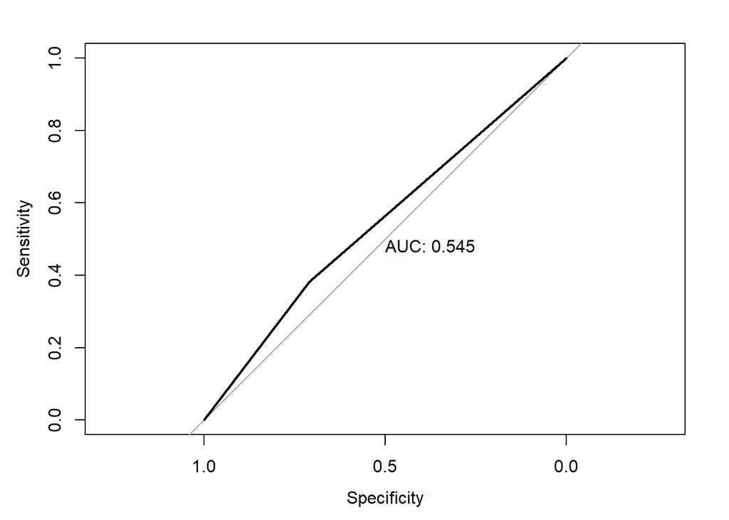

```r
roc1 = roc(Default$default~prob1, plot=TRUE, print.auc=TRUE)
```

```r
as.numeric(roc1$auc)
```

```
## [1] 0.5449888
```

ROC graph of Q1.3.i:

```r
prob2 = predict(ols4, type='response', data=Default)
pred2 = as.factor(ifelse(prob2>0.5, 'Yes', 'No'))
confusionMatrix(pred2, Default$default)
```

```
## Confusion Matrix and Statistics
##
##           Reference
## Prediction   No  Yes
##        No  9628  228
##        Yes   39  105
##
##                Accuracy : 0.9733
##                  95% CI : (0.9699, 0.9764)
##     No Information Rate : 0.9667
##     P-Value [Acc > NIR] : 8.229e-05
##
##                   Kappa : 0.4288
##
##  Mcnemar's Test P-Value : < 2.2e-16
##
##             Sensitivity : 0.9960
##             Specificity : 0.3153
##          Pos Pred Value : 0.9769
##          Neg Pred Value : 0.7292
##              Prevalence : 0.9667
##          Detection Rate : 0.9628
##    Detection Prevalence : 0.9856
##       Balanced Accuracy : 0.6556
##
##        'Positive' Class : No
##
```

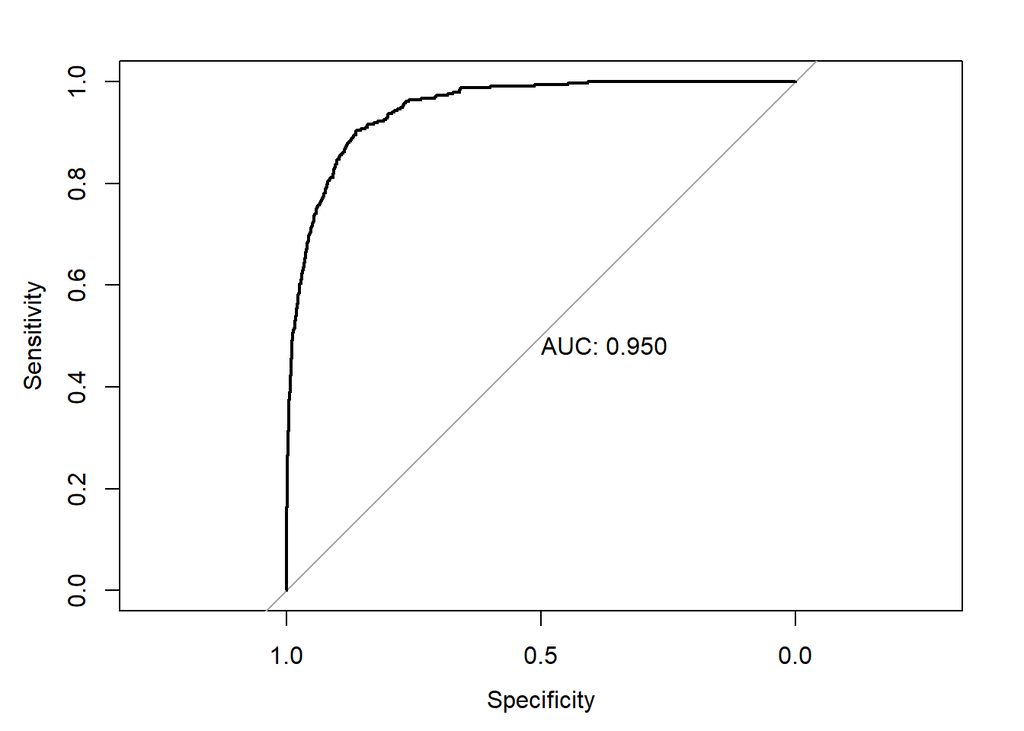

```r
roc2 = roc(Default$default~prob2, plot=TRUE, print.auc=TRUE)
```

```r
as.numeric(roc2$auc)
```

```
## [1] 0.9495476
```

The AUC of Q1.1 model is 54.5% and the AUC of Q1.3.i model is 95%. The Q1.3.i model is better than Q1.1 model.

### iii

```r
confusionMatrix(pred2, Default$default)
```

```
## Confusion Matrix and Statistics
##
##           Reference
## Prediction   No  Yes
##        No  9628  228
##        Yes   39  105
##
##                Accuracy : 0.9733
##                  95% CI : (0.9699, 0.9764)
##     No Information Rate : 0.9667
##     P-Value [Acc > NIR] : 8.229e-05
##
##                   Kappa : 0.4288
##
##  Mcnemar's Test P-Value : < 2.2e-16
##
##             Sensitivity : 0.9960
##             Specificity : 0.3153
##          Pos Pred Value : 0.9769
##          Neg Pred Value : 0.7292
##              Prevalence : 0.9667
##          Detection Rate : 0.9628
##    Detection Prevalence : 0.9856
##       Balanced Accuracy : 0.6556
##
##        'Positive' Class : No
##
```

$$Sensitivity : 0.9960\\
Specificity : 0.3153\\
False positive rate : 0.6847\\
True positive rate : 0.9960$$

# Q2

```r
datasale =  read.table('lostsales.txt', header=T, sep=',', na.strings = c("NA"))
```

Part.Type and Status are categorical variables.

```r
datasale$Part.Type <- as.factor(datasale$Part.Type)
datasale$Status <- as.factor(datasale$Status)
```

Make plots to see the relationships between variables.

```r
library(dplyr)
library(GGally)
```

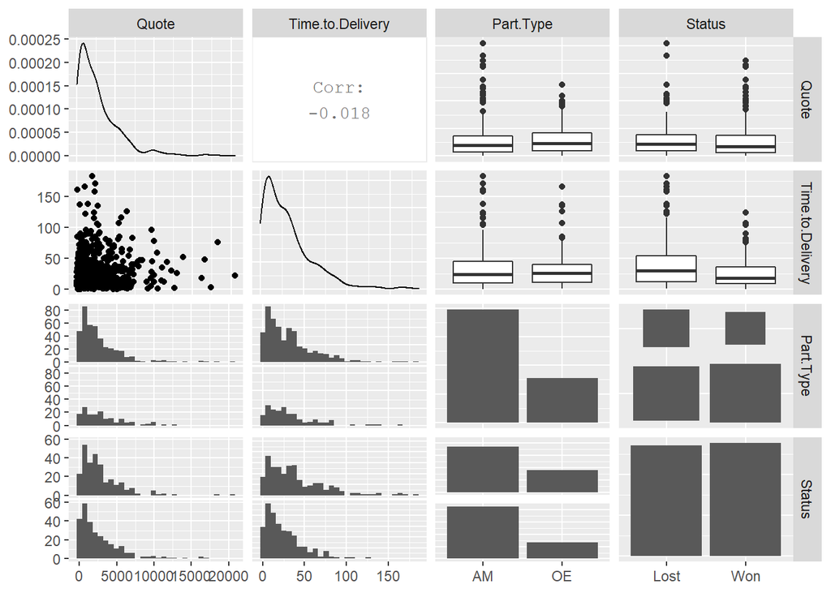

```r
datasale[,c(1:4)] %>%
ggpairs(progress=FALSE)
```

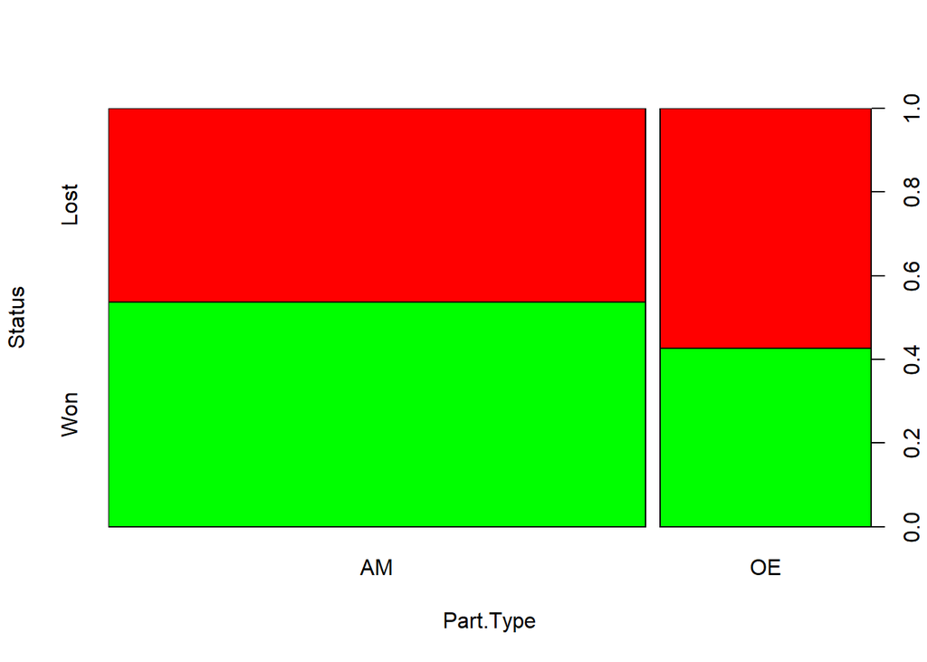

```r
plot(datasale$Part.Type, datasale$Status, xlab = "Part.Type", ylab ="Status", col = c('green','red'))
```

Make a general liner model.

```r
olssale <- glm(Status~., data=datasale, family = binomial(logit))
summary(olssale)
```

```
##
## Call:
## glm(formula = Status ~ ., family = binomial(logit), data = datasale)
##
## Deviance Residuals:
##    Min      1Q  Median      3Q     Max
## -1.497  -1.175   0.882   1.091   1.961
##
## Coefficients:
##                    Estimate Std. Error z value Pr(>|z|)
## (Intercept)       7.768e-01  1.712e-01   4.537 5.70e-06 ***
## Quote            -1.931e-05  3.073e-05  -0.628   0.5299
## Time.to.Delivery -1.837e-02  3.483e-03  -5.274 1.34e-07 ***
## Part.TypeOE      -4.711e-01  1.968e-01  -2.394   0.0167 *
## ---
## Signif. codes:  0 '***' 0.001 '**' 0.01 '*' 0.05 '.' 0.1 ' ' 1
##
## (Dispersion parameter for binomial family taken to be 1)
##
##     Null deviance: 762.40  on 549  degrees of freedom
## Residual deviance: 723.83  on 546  degrees of freedom
## AIC: 731.83
##
## Number of Fisher Scoring iterations: 4
```

Quote is not significant at 0.05 level.

```r
olssale2 <- glm(Status~., data=datasale[,-c(1)], family = binomial(logit))
summary(olssale2)
```

```
##
## Call:
## glm(formula = Status ~ ., family = binomial(logit), data = datasale[,
##     -c(1)])
##
## Deviance Residuals:
##     Min       1Q   Median       3Q      Max
## -1.4877  -1.1731   0.8893   1.0972   1.9394
##
## Coefficients:
##                   Estimate Std. Error z value Pr(>|z|)
## (Intercept)       0.723499   0.148345   4.877 1.08e-06 ***
## Time.to.Delivery -0.018344   0.003484  -5.266 1.39e-07 ***
## Part.TypeOE      -0.475768   0.196582  -2.420   0.0155 *
## ---
## Signif. codes:  0 '***' 0.001 '**' 0.01 '*' 0.05 '.' 0.1 ' ' 1
##
## (Dispersion parameter for binomial family taken to be 1)
##
##     Null deviance: 762.40  on 549  degrees of freedom
## Residual deviance: 724.22  on 547  degrees of freedom
## AIC: 730.22
##
## Number of Fisher Scoring iterations: 4
```

Compare the two models to see whether we should include Quote.

```r
anova(olssale, olssale2, test='Chisq')
```

```
## Analysis of Deviance Table
##
## Model 1: Status ~ Quote + Time.to.Delivery + Part.Type
## Model 2: Status ~ Time.to.Delivery + Part.Type
##   Resid. Df Resid. Dev Df Deviance Pr(>Chi)
## 1       546     723.83
## 2       547     724.22 -1 -0.39542   0.5295
```

According to the result, The chi-square value is not significant (0.53), indicating that the new model fits as well as the model with all variables. This confirms that the addition of the removed variable-Quote will not significantly improve the prediction accuracy of the equation. Thus we can use the simpler model.

```r
probsale = predict(olssale2, type='response', data=datasale)
predsale = as.factor(ifelse(probsale>0.5, 'Won', 'Lost'))
confusionMatrix(predsale, datasale$Status)
```

```
## Confusion Matrix and Statistics
##
##           Reference
## Prediction Lost Won
##       Lost  136  85
##       Won   136 193
##
##                Accuracy : 0.5982
##                  95% CI : (0.5559, 0.6394)
##     No Information Rate : 0.5055
##     P-Value [Acc > NIR] : 7.756e-06
##
##                   Kappa : 0.1946
##
##  Mcnemar's Test P-Value : 0.00077
##
##             Sensitivity : 0.5000
##             Specificity : 0.6942
##          Pos Pred Value : 0.6154
##          Neg Pred Value : 0.5866
##              Prevalence : 0.4945
##          Detection Rate : 0.2473
##    Detection Prevalence : 0.4018
##       Balanced Accuracy : 0.5971
##
##        'Positive' Class : Lost
##
```

**The final model:**

```r
summary(olssale2)
```

```
##
## Call:
## glm(formula = Status ~ ., family = binomial(logit), data = datasale[,
##     -c(1)])
##
## Deviance Residuals:
##     Min       1Q   Median       3Q      Max
## -1.4877  -1.1731   0.8893   1.0972   1.9394
##
## Coefficients:
##                   Estimate Std. Error z value Pr(>|z|)
## (Intercept)       0.723499   0.148345   4.877 1.08e-06 ***
## Time.to.Delivery -0.018344   0.003484  -5.266 1.39e-07 ***
## Part.TypeOE      -0.475768   0.196582  -2.420   0.0155 *
## ---
## Signif. codes:  0 '***' 0.001 '**' 0.01 '*' 0.05 '.' 0.1 ' ' 1
##
## (Dispersion parameter for binomial family taken to be 1)
##
##     Null deviance: 762.40  on 549  degrees of freedom
## Residual deviance: 724.22  on 547  degrees of freedom
## AIC: 730.22
##
## Number of Fisher Scoring iterations: 4
```

The increase of time makes it less likely that a customer will place an order. Comparing to original equipment, the aftermarket equipment makes the probability of order being placed higher.

# Q3

```r
datawine <- read.table('winequality-bc.txt',header=T,sep=',',na.strings = c("NA"))
```

For numeric variables:

```r
library(corrplot)
datawine2 <- datawine[,c(2:12, 14)]
cor(datawine2)
```

```
##                      fixed.acidity volatile.acidity citric.acid residual.sugar
## fixed.acidity           1.00000000       0.21900826  0.32443573    -0.11198128
## volatile.acidity        0.21900826       1.00000000 -0.37798132    -0.19601117
## citric.acid             0.32443573      -0.37798132  1.00000000     0.14245123
## residual.sugar         -0.11198128      -0.19601117  0.14245123     1.00000000
## chlorides               0.29819477       0.37712428  0.03899801    -0.12894050
## free.sulfur.dioxide    -0.28273543      -0.35255731  0.13312581     0.40287064
## total.sulfur.dioxide   -0.32905390      -0.41447619  0.19524198     0.49548159
## density                 0.45890998       0.27129565  0.09615393     0.55251695
## pH                     -0.25270047       0.26145440 -0.32980819    -0.26731984
## sulphates               0.29956774       0.22598368  0.05619730    -0.18592741
## alcohol                -0.09545152      -0.03764039 -0.01049349    -0.35941477
## quality                -0.07674321      -0.26569948  0.08553172    -0.03698048
##                        chlorides free.sulfur.dioxide total.sulfur.dioxide
## fixed.acidity         0.29819477         -0.28273543          -0.32905390
## volatile.acidity      0.37712428         -0.35255731          -0.41447619
## citric.acid           0.03899801          0.13312581           0.19524198
## residual.sugar       -0.12894050          0.40287064           0.49548159
## chlorides             1.00000000         -0.19504479          -0.27963045
## free.sulfur.dioxide  -0.19504479          1.00000000           0.72093408
## total.sulfur.dioxide -0.27963045          0.72093408           1.00000000
## density               0.36261466          0.02571684           0.03239451
## pH                    0.04470798         -0.14585390          -0.23841310
## sulphates             0.39559331         -0.18845725          -0.27572682
## alcohol              -0.25691558         -0.17983843          -0.26573964
## quality              -0.20066550          0.05546306          -0.04138545
##                          density          pH    sulphates      alcohol
## fixed.acidity         0.45890998 -0.25270047  0.299567744 -0.095451523
## volatile.acidity      0.27129565  0.26145440  0.225983680 -0.037640386
## citric.acid           0.09615393 -0.32980819  0.056197300 -0.010493492
## residual.sugar        0.55251695 -0.26731984 -0.185927405 -0.359414771
## chlorides             0.36261466  0.04470798  0.395593307 -0.256915580
## free.sulfur.dioxide   0.02571684 -0.14585390 -0.188457249 -0.179838435
## total.sulfur.dioxide  0.03239451 -0.23841310 -0.275726820 -0.265739639
## density               1.00000000  0.01168608  0.259478495 -0.686745422
## pH                    0.01168608  1.00000000  0.192123407  0.121248467
## sulphates             0.25947850  0.19212341  1.000000000 -0.003029195
## alcohol              -0.68674542  0.12124847 -0.003029195  1.000000000
## quality              -0.30585791  0.01950570  0.038485446  0.444318520
##                          quality
## fixed.acidity        -0.07674321
## volatile.acidity     -0.26569948
## citric.acid           0.08553172
## residual.sugar       -0.03698048
## chlorides            -0.20066550
## free.sulfur.dioxide   0.05546306
## total.sulfur.dioxide -0.04138545
## density              -0.30585791
## pH                    0.01950570
## sulphates             0.03848545
## alcohol               0.44431852
## quality               1.00000000
```

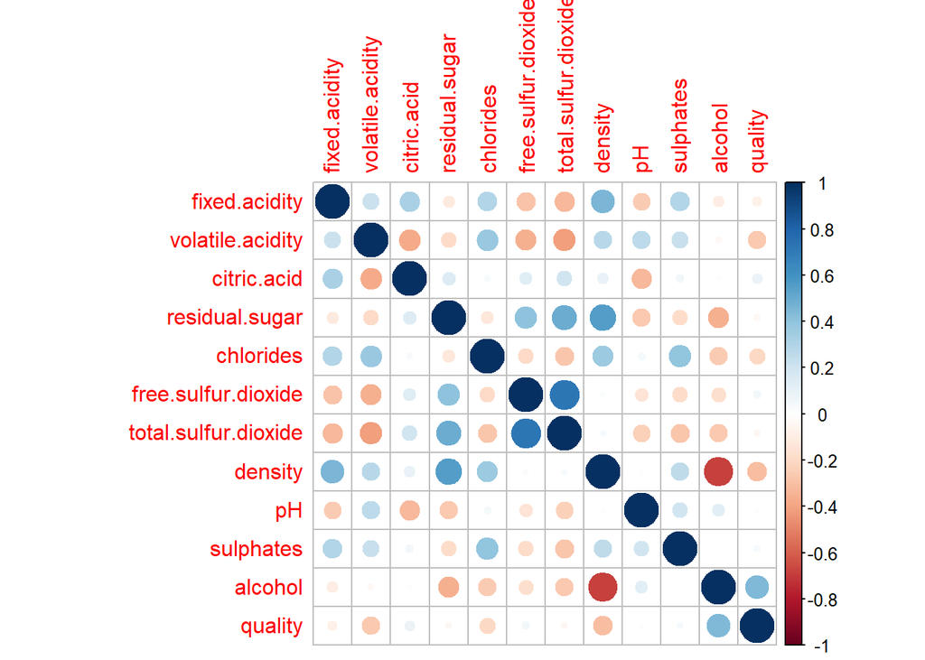

```r
corrplot(cor(datawine2))
```

Alcohol, volatile.acidity, density and chlorides are related to quality. Free.sulfur.dioxide and total.sulfur.dioxide are highly related. Density and alcohol are highly related.

For all variables:

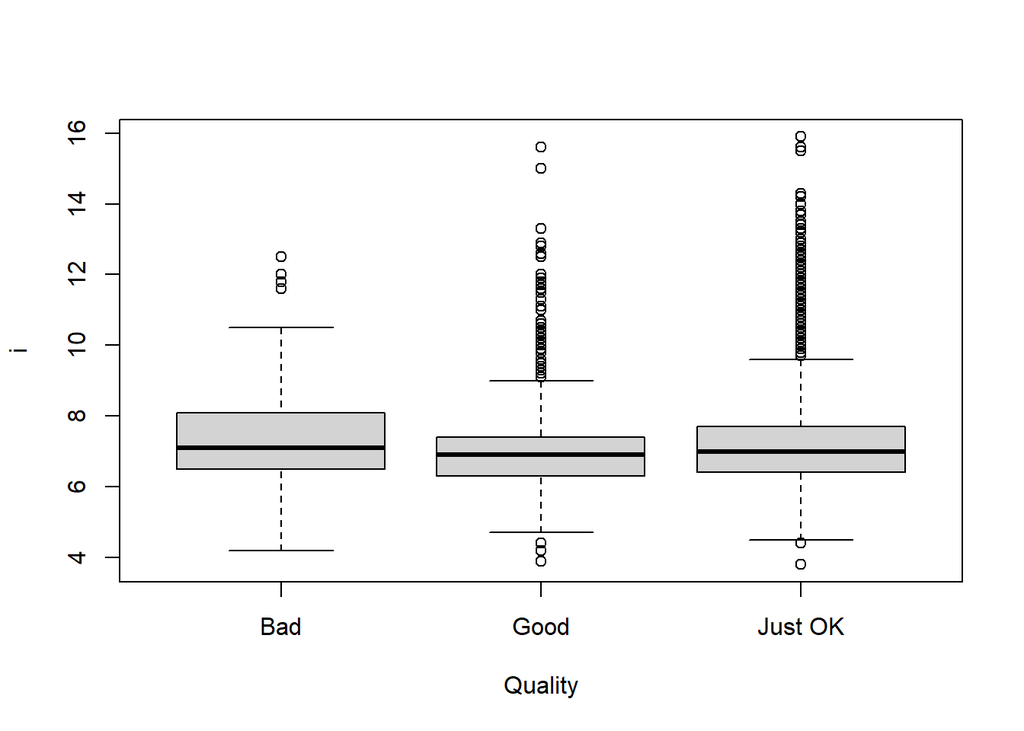

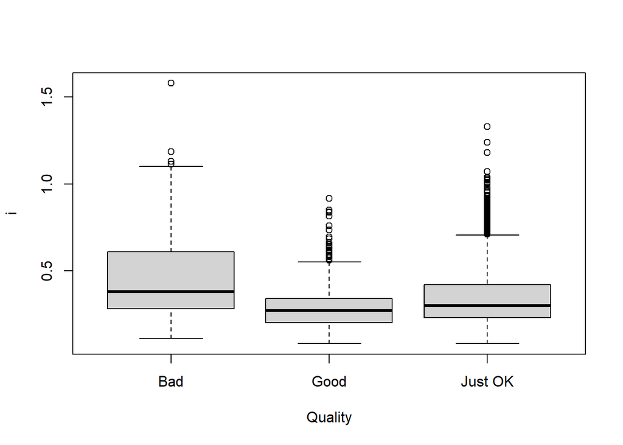

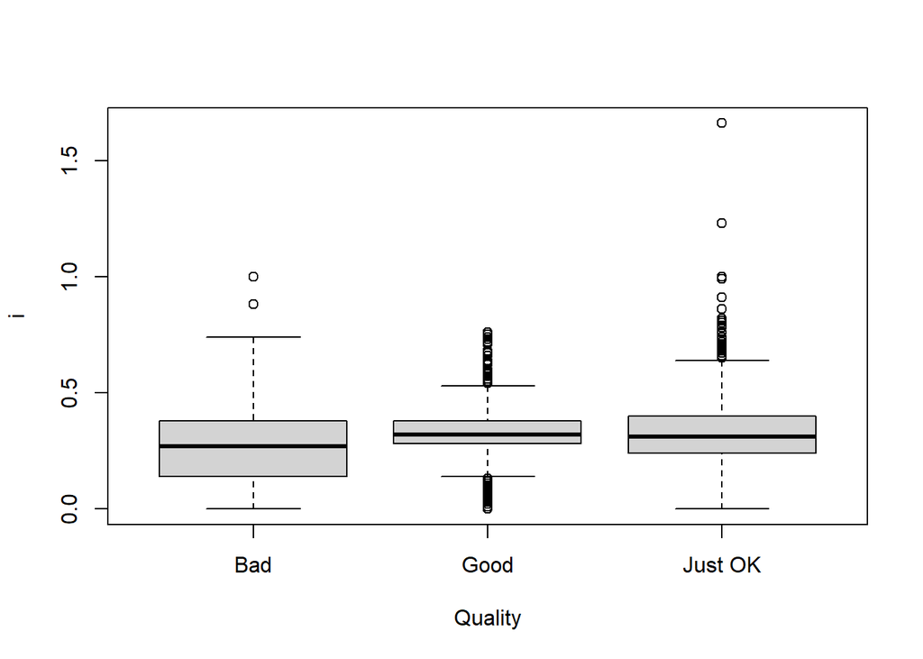

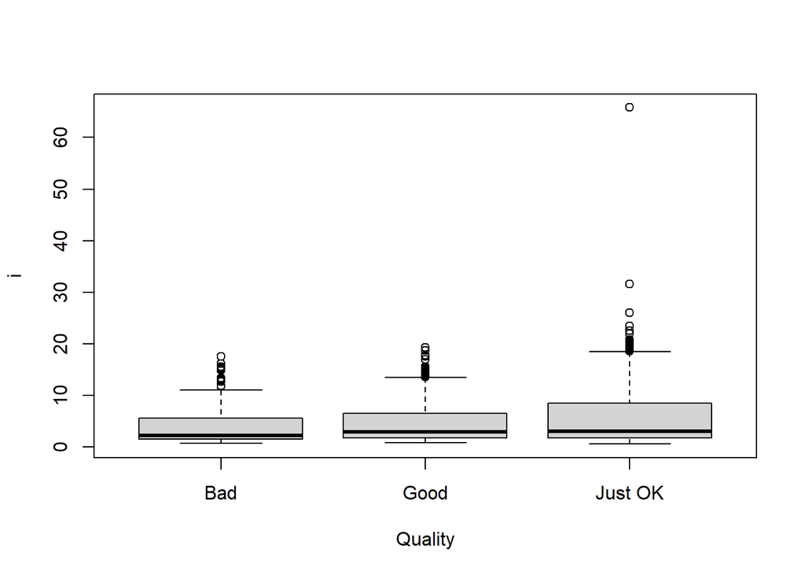

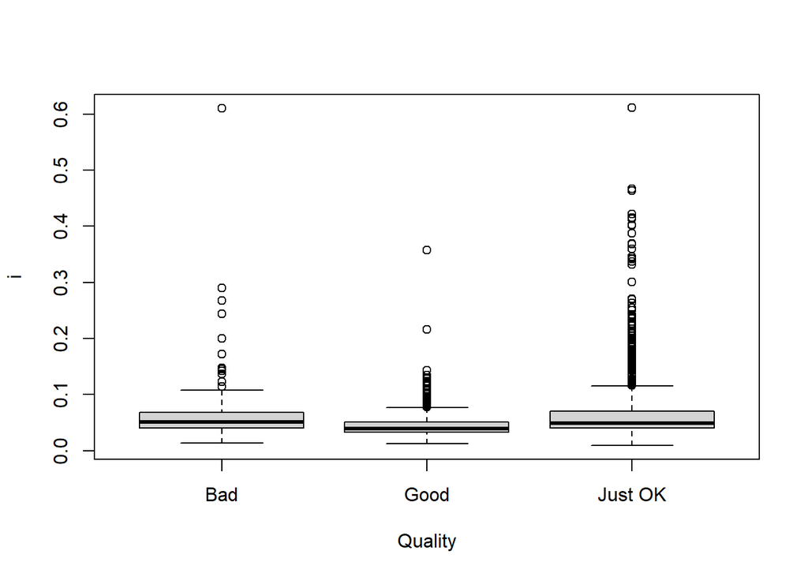

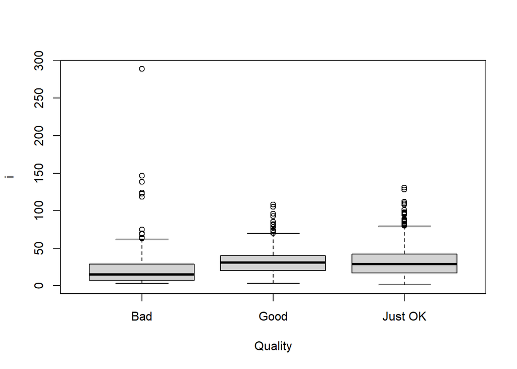

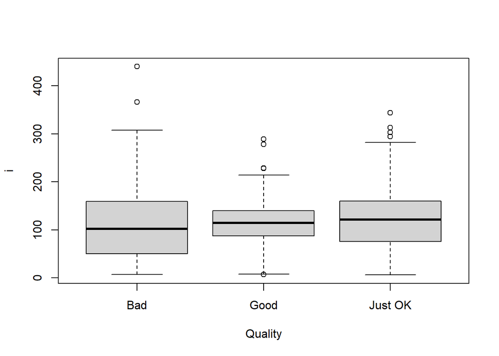

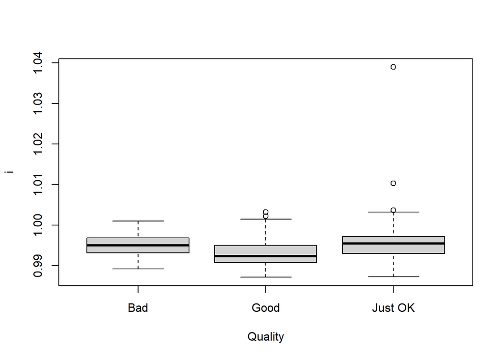

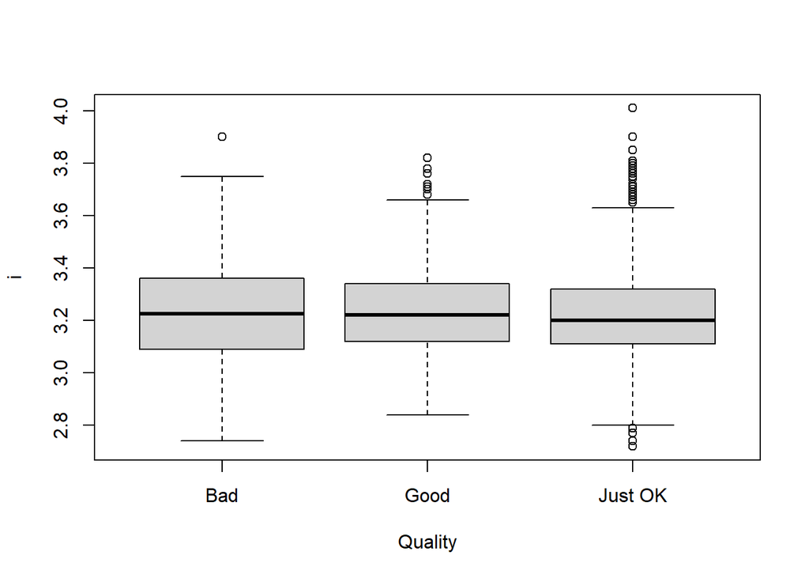

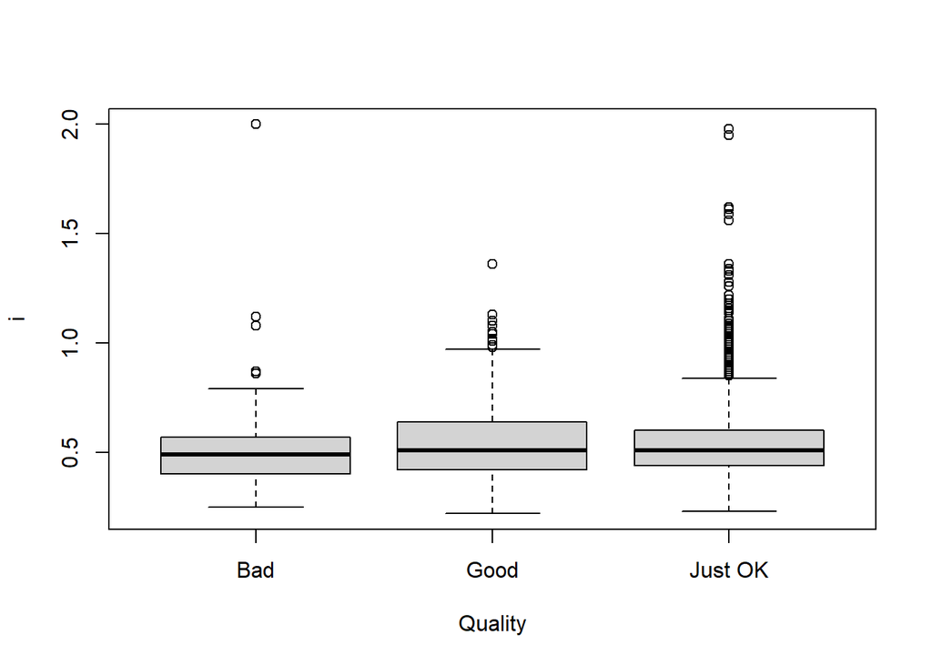

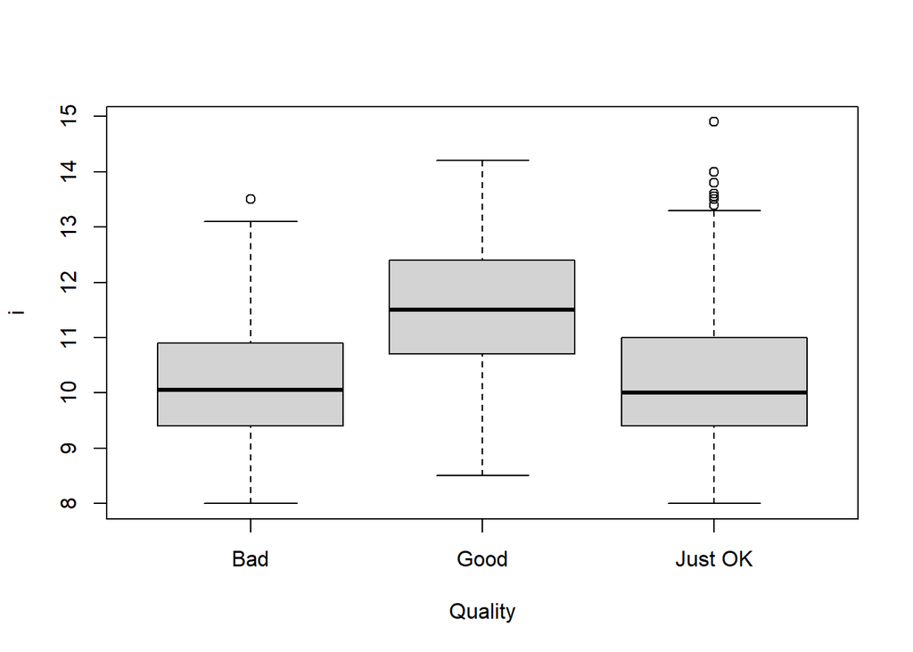

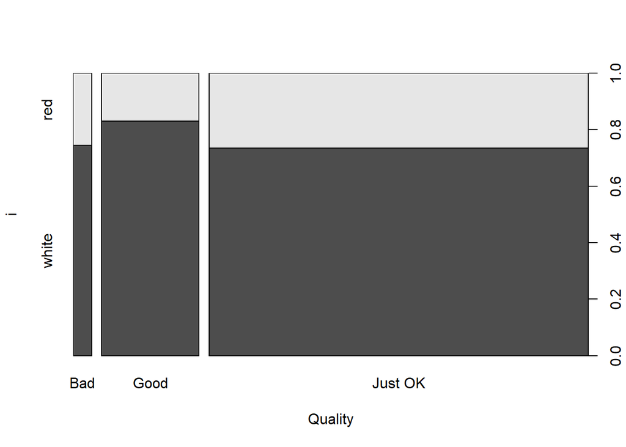

```r
datawine$Quality <- as.factor(datawine$Quality)
datawine$color <- as.factor(datawine$color)
for (i in datawine[, c(2:13)])
{plot(i~Quality, datawine)}
```

## LDA model

```r
library(MASS)
library(dplyr)
```

```r
datawine3 <- datawine[,-c(14:16)]
datawine3$Quality <- as.factor(datawine3$Quality)
datawine3$Quality <- relevel(datawine3$Quality, ref='Just OK')
```

```r
set.seed(0)
train = sample(nrow(datawine3), 0.8*nrow(datawine3))
datatrain <- datawine3[train,]
datatest <- datawine3[-train,]
```

train the model:

```r
olswine1 <- lda(Quality~., datatrain)
olswine1
```

```
## Call:
## lda(Quality ~ ., data = datatrain)
##
## Prior probabilities of groups:
##   Just OK       Bad      Good
## 0.7652492 0.0359823 0.1987685
##
## Group means:
##         fixed.acidity volatile.acidity citric.acid residual.sugar  chlorides
## Just OK      7.249309        0.3475019   0.3175911       5.652615 0.05919060
## Bad          7.214973        0.4715508   0.2607487       4.389840 0.06161497
## Good         7.070620        0.2876041   0.3345402       4.795402 0.04439690
##         free.sulfur.dioxide total.sulfur.dioxide   density       pH sulphates
## Just OK            30.82235             117.5425 0.9951317 3.214355 0.5319864
## Bad                23.63369             105.0829 0.9949204 3.244171 0.5087701
## Good               31.26137             110.6244 0.9929958 3.230039 0.5403969
##          alcohol colorwhite
## Just OK 10.26558  0.7301986
## Bad     10.20053  0.7326203
## Good    11.43971  0.8334947
##
## Coefficients of linear discriminants:
##                                LD1           LD2
## fixed.acidity         3.475323e-01  -0.200721509
## volatile.acidity     -2.475776e+00  -6.622877156
## citric.acid          -3.070584e-02   0.468393877
## residual.sugar        1.808787e-01   0.057795304
## chlorides            -1.912128e+00  -0.121241476
## free.sulfur.dioxide   8.504309e-03   0.006264320
## total.sulfur.dioxide -1.860237e-03   0.008398393
## density              -3.657045e+02 -44.627386452
## pH                    1.839080e+00  -1.500054806
## sulphates             1.826530e+00  -0.418509014
## alcohol               4.305459e-01  -0.147111959
## colorwhite           -8.603457e-01  -3.697868468
##
## Proportion of trace:
##    LD1    LD2
## 0.8575 0.1425
```

Good wine seems to be high citric.acid, free.sulfur.dioxide, sulphates, alcohol and low fixed.acidity, volatile.acidity, chlorides than the other wines. White wine is more likely to be good than red wine.

test the model:

```r
lda.pred = predict(olswine1, datatest)
lda.class = lda.pred$class
table(lda.class, datatest$Quality)
```

```
##
## lda.class Just OK Bad Good
##   Just OK     927  50  162
##   Bad           5   8    0
##   Good         65   1   82
```

**prediction accuracy:**

```r
mean(lda.class == datatest$Quality)
```

```
## [1] 0.7823077
```

## Multinomial Logistic Regression

```r
library(tidyverse)
library(caret)
library(nnet)
```

train the model:

```r
olswine2 <- multinom(Quality~., data=datatrain)
summary(olswine2)
```

```
## Call:
## multinom(formula = Quality ~ ., data = datatrain)
##
## Coefficients:
##      (Intercept) fixed.acidity volatile.acidity citric.acid residual.sugar
## Bad    -104.4606     0.1420628         5.193831  -0.8752280    -0.09738124
## Good    422.0841     0.5356397        -3.682063  -0.4524189     0.22228226
##      chlorides free.sulfur.dioxide total.sulfur.dioxide    density       pH
## Bad   2.318443        -0.016507691         -0.004731317   96.09858 1.095575
## Good -7.934667         0.008762437         -0.003458867 -444.07454 2.916189
##       sulphates    alcohol colorwhite
## Bad  -0.3405973 -0.1612524  3.4966537
## Good  2.3448124  0.4343602 -0.7037211
##
## Std. Errors:
##      (Intercept) fixed.acidity volatile.acidity citric.acid residual.sugar
## Bad    1.0865493    0.08563403        0.5366073   0.6609451     0.01968077
## Good   0.6961818    0.04678539        0.4371347   0.3775358     0.01093754
##       chlorides free.sulfur.dioxide total.sulfur.dioxide   density        pH
## Bad  0.77918536         0.007433576          0.002730766 1.0656918 0.5489202
## Good 0.08365697         0.003222947          0.001465999 0.6868034 0.3077535
##      sulphates    alcohol colorwhite
## Bad  0.6926193 0.08267257  0.3938049
## Good 0.3055013 0.04128505  0.2045591
##
## Residual Deviance: 5395.148
## AIC: 5447.148
```

```r
p <- 2*(1-pnorm(abs(summary(olswine2)$coefficients/summary(olswine2)$standard.errors)))
p
```

```
##      (Intercept) fixed.acidity volatile.acidity citric.acid residual.sugar
## Bad            0    0.09712545                0   0.1854344   7.496452e-07
## Good           0    0.00000000                0   0.2307820   0.000000e+00
##        chlorides free.sulfur.dioxide total.sulfur.dioxide density        pH
## Bad  0.002925401         0.026371755           0.08316738       0 0.0459478
## Good 0.000000000         0.006552604           0.01830484       0 0.0000000
##         sulphates    alcohol   colorwhite
## Bad  6.228943e-01 0.05111721 0.0000000000
## Good 1.643130e-14 0.00000000 0.0005813163
```

citric.acid is not significant.

Since free.sulfur.dioxide and total.sulfur.dioxide are highly related and density and alcohol are highly related. We exclude total.sulfur.dioxide and density.

final training model:

```r
olswine3 <- multinom(Quality~., data=datatrain[, -c(4, 8:9)])
summary(olswine3)
```

```
## Call:
## multinom(formula = Quality ~ ., data = datatrain[, -c(4, 8:9)])
##
## Coefficients:
##      (Intercept) fixed.acidity volatile.acidity residual.sugar  chlorides
## Bad    -9.763488     0.1669253         5.332628    -0.06320175   1.734951
## Good  -15.445980     0.1415654        -3.972320     0.04837065 -12.842456
##      free.sulfur.dioxide       pH sulphates    alcohol colorwhite
## Bad         -0.025436326 1.516513 -0.465264 -0.2394144  2.8320730
## Good         0.004790823 1.181986  1.596750  0.9268655 -0.2094672
##
## Std. Errors:
##      (Intercept) fixed.acidity volatile.acidity residual.sugar chlorides
## Bad      2.63392    0.08290912        0.5065656     0.02195357  2.397245
## Good     1.35987    0.04160682        0.4121284     0.01014834  2.995379
##      free.sulfur.dioxide        pH sulphates    alcohol colorwhite
## Bad          0.006211365 0.6166108 0.7075633 0.08217448  0.3413858
## Good         0.002564039 0.2980553 0.3048551 0.04118626  0.1958903
##
## Residual Deviance: 5456.267
## AIC: 5496.267
```

Good wine seems to be higher fixed.acidity, residual.sugar, free.sulfur.dioxide, pH, sulphates, alcohol and lower volatile.acidity, chlorides than Just OK wine.

test the model:

```r
datatest2 <- datatest[, -c(4, 8:9)]
pred2 = predict(olswine3, newdata = datatest2)
table(datatest2$Quality, pred2)
```

```
##          pred2
##           Just OK Bad Good
##   Just OK     942   1   54
##   Bad          57   2    0
##   Good        180   0   64
```

```r
confusionMatrix(factor(pred2), factor(datatest2$Quality))
```

```
## Confusion Matrix and Statistics
##
##           Reference
## Prediction Just OK Bad Good
##    Just OK     942  57  180
##    Bad           1   2    0
##    Good         54   0   64
##
## Overall Statistics
##
##                Accuracy : 0.7754
##                  95% CI : (0.7517, 0.7978)
##     No Information Rate : 0.7669
##     P-Value [Acc > NIR] : 0.2464
##
##                   Kappa : 0.2182
##
##  Mcnemar's Test P-Value : NA
##
## Statistics by Class:
##
##                      Class: Just OK Class: Bad Class: Good
## Sensitivity                  0.9448   0.033898     0.26230
## Specificity                  0.2178   0.999194     0.94886
## Pos Pred Value               0.7990   0.666667     0.54237
## Neg Pred Value               0.5455   0.956052     0.84772
## Prevalence                   0.7669   0.045385     0.18769
## Detection Rate               0.7246   0.001538     0.04923
## Detection Prevalence         0.9069   0.002308     0.09077
## Balanced Accuracy            0.5813   0.516546     0.60558
```

**prediction accuracy:**

```r
mean(pred2 == datatest2$Quality)
```

```
## [1] 0.7753846
```

## Conclusion

**Good** quality wine seems to be:

- high free.sulfur.dioxide, sulphates, alcohol;
- low volatile.acidity, chlorides.

The results of LDA and multinomial logistic regression is different in fixed.acidity, residual.sugar and color.

To explore these differences, we need to take into account the interaction terms for further analysis.